# 1D-Continuous Dynamical Systems (Assignment Sheet 1)

Introduction To Chaos Applied To Systems, Processes And Products (ETSIDI, UPM)

Alfonso Allen-Perkins, Juan Carlos Bueno and Eduardo Faleiro

2026-02-19

## 1. The logistic growth model

The logistic growth model describes how a population grows when there are limited resources. A common form of the logistic growth model is

$\frac{dN}{dt}=\dot{N}=rN \cdot \left(1-\frac{N}{K}\right)$.

Here, $N(t)$ represents the population size at time $t$. The parameter $r>0$ is the growth rate, which controls how fast the population increases when it is small. The parameter $K>0$ is the carrying capacity, the maximum population size that the environment can support. When $N$ is much smaller than $K$, the population grows almost exponentially. As $N$ approaches $K$, growth slows down and eventually stops.

## Numeric solutions of the logistic growth model

We want to solve the differential equation of the logistic growth model, but instead of solving it by hand, we approximate $N(t)$ numerically on a grid of time points. In R, the `deSolve` package does this for us: we define a function that returns $\dot{N}$, choose parameter values $(r,K)$, pick an initial population $N(0)=N0$, and then call `ode()` to compute the solution over time.

### Step 1.1: Load packages

```r
library(deSolve)
library(ggplot2)
```

### Step 1.2: Define the logistic ODE

We code the equation

$\frac{dN}{dt} = r N\cdot\left(1-\frac{N}{K}\right)$

as a function that returns $dN/dt$.

```r
logistic_ode <- function(t, state, parameters) {

  # Population size
  N <- state["N"]

  # Parameters
  r <- parameters["r"]
  K <- parameters["K"]

  # Logistic growth equation
  dN <- r * N * (1 - N / K)

  # Return the derivative
  list(c(dN))
}
```

### Step 1.3: Choose parameters and initial condition

```r
# Growth rate
r <- 0.4

# Carrying capacity
K <- 100

# Initial population size
N0 <- 10
```

### Step 1.4: Define the time interval

```r
# Time points where the solution is computed
times <- seq(from = 0, to = 30, by = 0.1)
```

### Step 1.5: Run the numerical integration

`ode()` returns a matrix-like object; we convert it to a data frame.

```r
# Numerical integration of the logistic equation
solution <- ode(
  y = c(N = N0),
  times = times,
  func = logistic_ode,
  parms = c(r = r, K = K)
)

# Convert output to a data frame
solution <- as.data.frame(solution)

# Show the first few rows
head(solution)
```

```
##   time        N
## 1  0.0 10.00000
## 2  0.1 10.36581
## 3  0.2 10.74340
## 4  0.3 11.13303
## 5  0.4 11.53497
## 6  0.5 11.94947
```

### Step 1.6: Plot $N(t)$ and show the carrying capacity $K$

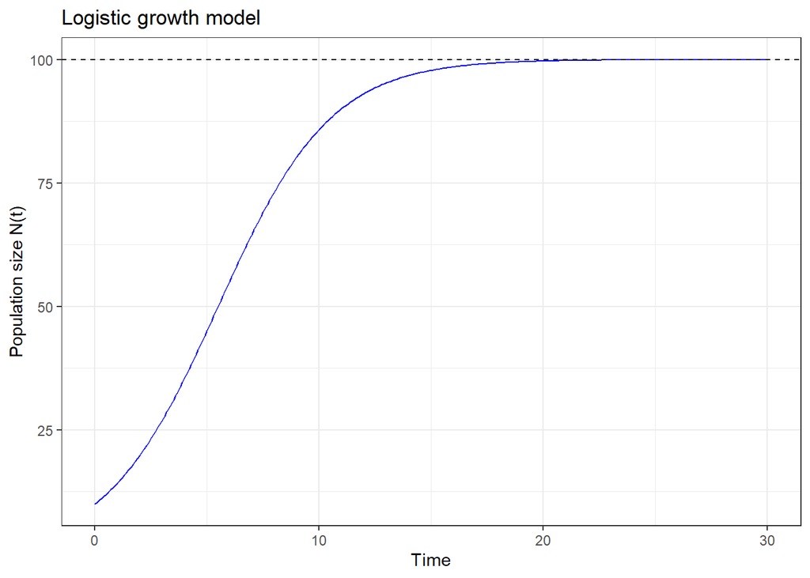

```r
# Create a plot using the data frame for the logistic model
ggplot(data = solution, aes(x = time, y = N)) +

  # Add a line representing N(t)
  geom_line(color = "blue") +

  # Add a horizontal line for the carrying capacity K
  geom_hline(yintercept = K, linetype = "dashed") +

  # Label the x-axis
  xlab("Time") +

  # Label the y-axis
  ylab("Population size N(t)") +

  # Add a title to the plot
  ggtitle("Logistic growth model") +

  # Use a clean black-and-white theme
  theme_bw()
```

### Step 1.7: Compare different initial conditions (same $r, K$)

Here we keep $r$ and $K$ fixed, but try $N_0 < K$, $N_0 = K$, and $N_0 > K$.

```r
# Three initial conditions
N0_1 <- 10    # N0 < K
N0_2 <- K     # N0 = K
N0_3 <- 150   # N0 > K

# Solve the model for N0 = 10
solution1 <- ode(
  y = c(N = N0_1),
  times = times,
  func = logistic_ode,
  parms = c(r = r, K = K)
)
solution1 <- as.data.frame(solution1)

# Solve the model for N0 = K
solution2 <- ode(
  y = c(N = N0_2),
  times = times,
  func = logistic_ode,
  parms = c(r = r, K = K)
)
solution2 <- as.data.frame(solution2)

# Solve the model for N0 = 150
solution3 <- ode(
  y = c(N = N0_3),
  times = times,
  func = logistic_ode,
  parms = c(r = r, K = K)
)
solution3 <- as.data.frame(solution3)
```

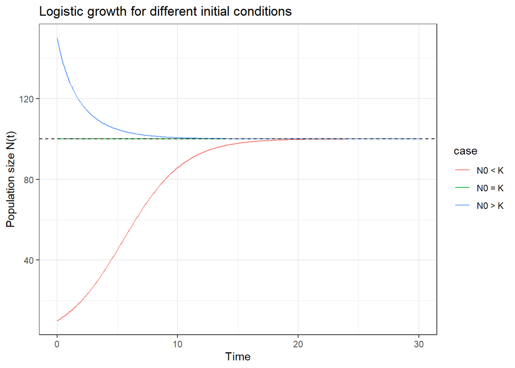

```r
# Add a label so we can tell the curves apart
solution1$case <- "N0 < K"
solution2$case <- "N0 = K"
solution3$case <- "N0 > K"

# Combine all solutions into one data frame
all_solutions <- rbind(solution1, solution2, solution3)

# Create the plot
ggplot(data = all_solutions, aes(x = time, y = N, color = case)) +

  # Draw one line for each initial condition
  geom_line() +

  # Show the carrying capacity K
  geom_hline(yintercept = K, linetype = "dashed") +

  # Label the axes
  xlab("Time") +
  ylab("Population size N(t)") +

  # Title
  ggtitle("Logistic growth for different initial conditions") +

  # Clean theme
  theme_bw()
```

**What to notice:**

- If $N_0 < K$, the solution increases toward $K$.
- If $N_0 > K$, it decreases toward $K$.
- If $N_0 = K$, it stays at $K$.

### Step 1.9: Compare different growth rates $r$ (same $N_0, K$)

Now we keep $N_0$ and $K$ fixed, and change $r$.

```r
# Fix the initial condition and carrying capacity
N0_fixed <- 10
K_fixed  <- K

# Three different growth rates
r1 <- 0.1
r2 <- 0.4
r3 <- 1.2

# Solve the model for r = 0.1
solution_r1 <- ode(
  y = c(N = N0_fixed),
  times = times,
  func = logistic_ode,
  parms = c(r = r1, K = K_fixed)
)
solution_r1 <- as.data.frame(solution_r1)

# Solve the model for r = 0.4
solution_r2 <- ode(
  y = c(N = N0_fixed),
  times = times,
  func = logistic_ode,
  parms = c(r = r2, K = K_fixed)
)
solution_r2 <- as.data.frame(solution_r2)

# Solve the model for r = 1.2
solution_r3 <- ode(
  y = c(N = N0_fixed),
  times = times,
  func = logistic_ode,
  parms = c(r = r3, K = K_fixed)
)
solution_r3 <- as.data.frame(solution_r3)
```

### Step 1.10: Plot the solutions for different growth rates

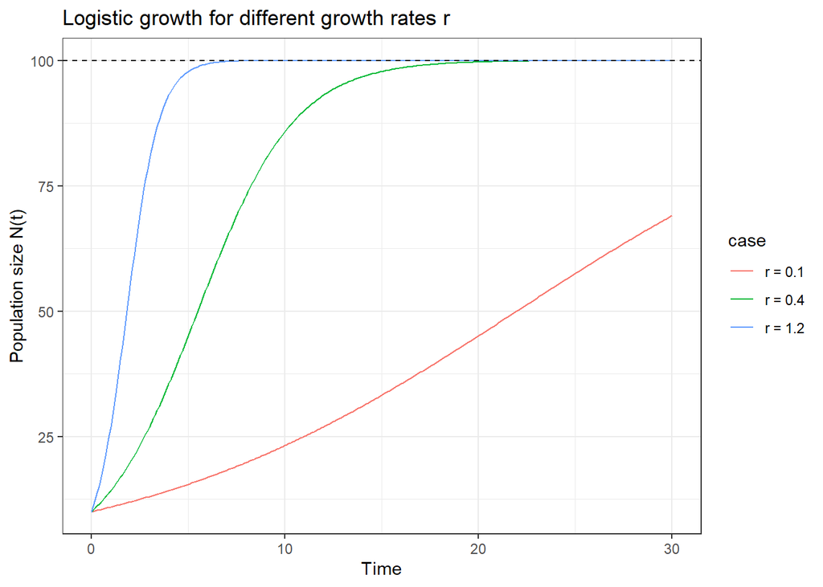

```r
# Add labels so we can tell the curves apart
solution_r1$case <- "r = 0.1"
solution_r2$case <- "r = 0.4"
solution_r3$case <- "r = 1.2"

# Combine all solutions into one data frame
all_r_solutions <- rbind(solution_r1, solution_r2, solution_r3)

# Create the plot
ggplot(data = all_r_solutions, aes(x = time, y = N, color = case)) +

  # Draw one line for each growth rate
  geom_line() +

  # Show the carrying capacity K
  geom_hline(yintercept = K_fixed, linetype = "dashed") +

  # Label the axes
  xlab("Time") +
  ylab("Population size N(t)") +

  # Title
  ggtitle("Logistic growth for different growth rates r") +

  # Clean black-and-white theme
  theme_bw()
```

## 2. Fixed points of the logistic growth model

For the continuous-time logistic model:

a fixed point (also called an equilibrium) is a value $N^*$ where $\frac{dN}{dt}=\dot{N}=0$. We can find these graphically and numerically.

```r
# f(N) = dN/dt
f <- function(N) {
  r * N * (1 - N / K)
}
```

### Step 2.2: Find fixed points analytically (one line)

Because $rN(1-N/K)=0$, the fixed points are:

- $N^* = 0$
- $N^* = K$

(We’ll now “see” them in plots and confirm numerically.)

### Step 2.3: Graphical method: plot $f(N)$ and look where it crosses 0

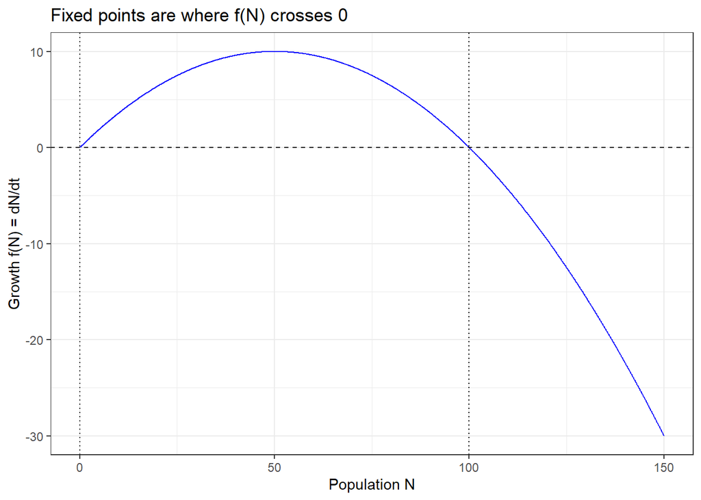

```r
# Create a grid of N values to plot f(N)
N_grid <- seq(0, 1.5*K, by = 0.1)

data_f <- data.frame(
  N = N_grid,
  dNdt = f(N_grid)
)

# Plot f(N) = dN/dt
ggplot(data = data_f, aes(x = N, y = dNdt)) +

  # The curve f(N)
  geom_line(color = "blue") +

  # The line y = 0 (where fixed points happen)
  geom_hline(yintercept = 0, linetype = "dashed") +

  # Mark the fixed points we expect: 0 and K
  geom_vline(xintercept = c(0, K), linetype = "dotted") +

  # Labels
  xlab("Population N") +
  ylab("Growth f(N) = dN/dt") +
  ggtitle("Fixed points are where f(N) crosses 0") +

  theme_bw()
```

### Step 2.4: Numerical method: use `uniroot()` to solve $f(N)=0$

`uniroot()` needs an interval where the function changes sign.

#### 2.4.1 Fixed point near $N=0$

```r
# Root near 0 (choose an interval close to 0)
root0 <- uniroot(f, interval = c(0, 1))$root
root0
```

```
## [1] 0
```

#### 2.4.2 Fixed point near $N=K$

```r
# Root near K (choose an interval around K)
rootK <- uniroot(f, interval = c(0.5*K, 1.5*K))$root
rootK
```

```
## [1] 99.99999
```

### Step 2.5: Add the numerically found fixed points to the plot

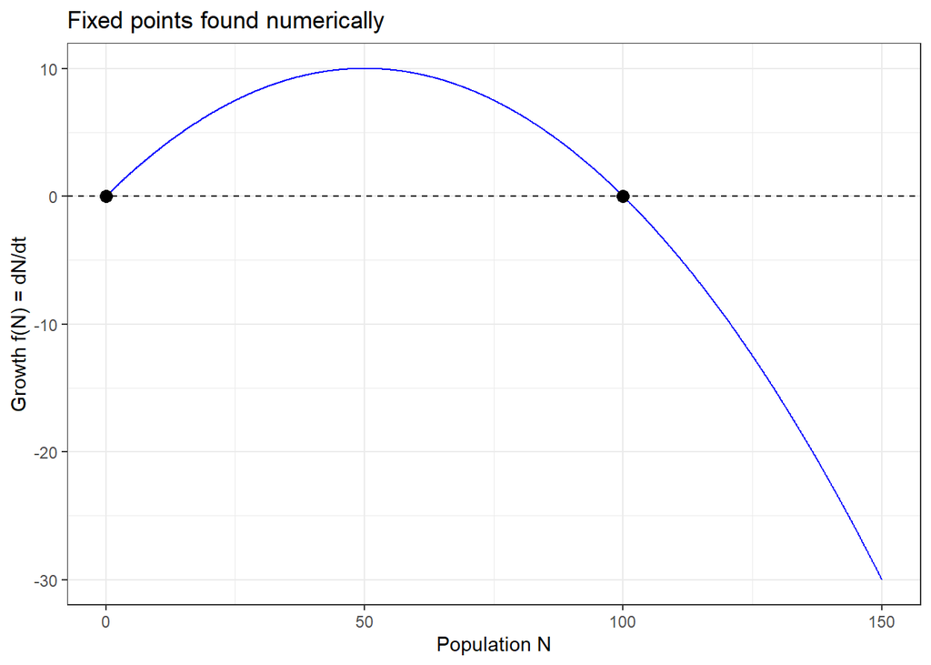

```r
fixed_points <- data.frame(
  N = c(root0, rootK),
  dNdt = c(f(root0), f(rootK)),
  label = c("root near 0", "root near K")
)

ggplot(data = data_f, aes(x = N, y = dNdt)) +
  geom_line(color = "blue") +
  geom_hline(yintercept = 0, linetype = "dashed") +
  geom_point(data = fixed_points, aes(x = N, y = dNdt), size = 3) +
  labs(
    x = "Population N",
    y = "Growth f(N) = dN/dt",
    title = "Fixed points found numerically"
  ) +
  theme_bw()
```

## 3. Linear stability analysis of the fixed points of the logistic growth model

For a 1D ODE of the form

$\frac{dN}{dt}=\dot{N}=f(N)$,

a fixed point $N^*$ is linearly stable if the slope $f'(N^*)<0$, and unstable if $f'(N^*)>0$. (If $f'(N^*)=0$, linearization is inconclusive.)

For the logistic model, $f(N)=rN \cdot \left(1-\frac{N}{K}\right)$.

### Step 3.1: Define $f(N)$ and its derivative $f'(N)$

```r
# f(N) = dN/dt
f <- function(N) {
  r * N * (1 - N / K)
}

# Derivative f'(N) (computed by hand)
fprime <- function(N) {
  r * (1 - 2 * N / K)
}
```

### Step 3.2: Linear stability numerically (evaluate the slope at the fixed points)

Assume you already computed `root0` and `rootK` with `uniroot()` (as in the previous step).

```r
# Slopes at the fixed points
slope0 <- fprime(root0)
slopeK <- fprime(rootK)

slope0
```

```
## [1] 0.4
```

```r
slopeK
```

```
## [1] -0.3999999
```

For logistic growth (with $r > 0$):

- at $N^* \approx 0$, slope is positive → **unstable**
- at $N^* \approx K$, slope is negative → **stable**

### Step 3.3: Graphical stability (plot $f(N)$ and show the tangent slope at the fixed points)

This plot shows the curve $f(N)$, the line $y=0$, and the **tangent lines** at each fixed point.

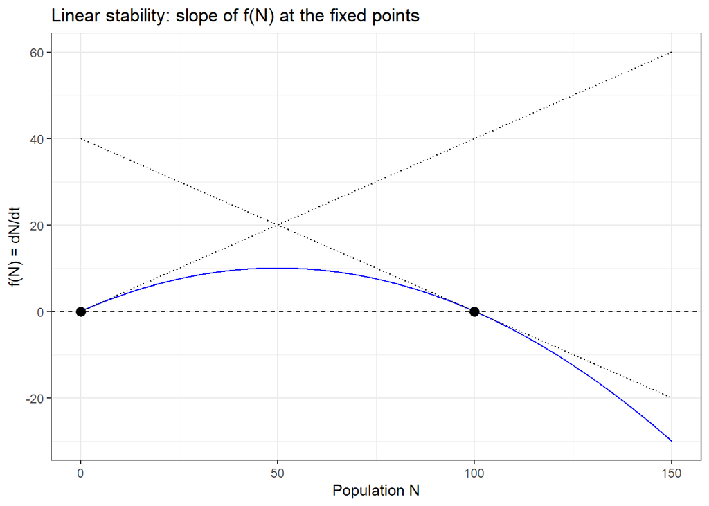

```r
# Grid for plotting f(N)
N_grid <- seq(0, 1.5*K, by = 0.1)

data_f <- data.frame(
  N = N_grid,
  dNdt = f(N_grid)
)

# Build tangent lines: y = f'(N*) (N - N*) + f(N*)
# But f(N*) = 0 at fixed points, so: y = f'(N*) (N - N*)
tangent <- function(N, Nstar) {
  fprime(Nstar) * (N - Nstar)
}

data_tan0 <- data.frame(N = N_grid, y = tangent(N_grid, root0), which = "tangent at N* ~ 0")
data_tanK <- data.frame(N = N_grid, y = tangent(N_grid, rootK), which = "tangent at N* ~ K")

ggplot(data_f, aes(x = N, y = dNdt)) +
  geom_line(color = "blue") +
  geom_hline(yintercept = 0, linetype = "dashed") +
  geom_point(data = data.frame(N = c(root0, rootK), dNdt = c(0, 0)),
             aes(x = N, y = dNdt), size = 3) +
  geom_line(data = data_tan0, aes(x = N, y = y), linetype = "dotted") +
  geom_line(data = data_tanK, aes(x = N, y = y), linetype = "dotted") +
  xlab("Population N") +
  ylab("f(N) = dN/dt") +
  ggtitle("Linear stability: slope of f(N) at the fixed points") +
  theme_bw()
```

At each fixed point, look at the *tilt* of the dotted tangent line:

- tangent slope **upward** (positive) → unstable
- tangent slope **downward** (negative) → stable

### Step 3.4: Numerical derivative (finite difference) as a “no-calculus” check

This estimates $f'(N)$ using nearby values of $f$.

```r
# Numerical derivative of f using a small step h
num_derivative <- function(N, h = 1e-6) {
  (f(N + h) - f(N - h)) / (2 * h)
}

num_slope0 <- num_derivative(root0)
num_slopeK <- num_derivative(rootK)

num_slope0
```

```
## [1] 0.4
```

```r
num_slopeK
```

```
## [1] -0.3999999
```

This should agree with `fprime(root0)` and `fprime(rootK)` (up to small numerical error).

### Step 3.5: Put results in a simple table

```r
results <- data.frame(
  fixed_point = c("N* near 0", "N* near K"),
  Nstar = c(root0, rootK),
  slope_exact = c(slope0, slopeK),
  slope_numeric = c(num_slope0, num_slopeK)
)

results
```

```
##   fixed_point    Nstar slope_exact slope_numeric
## 1   N* near 0  0.00000   0.4000000     0.4000000
## 2   N* near K 99.99999  -0.3999999    -0.3999999
```

## A note on the linear stability of fixed points

Consider a one-dimensional dynamical system of the form

$\frac{dN}{dt}=f(N)$,

and let $N^*$ be a fixed point, meaning that $f(N^*)=0$.

To study the stability of $N^*$, we look at what happens when the system starts close to this value. Suppose the population is slightly perturbed:

$N(t)=N^* +\varepsilon(t)$,

where $\varepsilon(t)$ is small. The key question is whether this perturbation grows or shrinks over time.

Near the fixed point, the function $f(N)$ can be approximated by its linear (first-order) Taylor expansion:

$\frac{d}{dt}\left( N^*+\varepsilon \right)=f(N^* +\varepsilon(t)) \rightarrow 0+\frac{d \varepsilon}{dt}=f(N^* +\varepsilon(t))\approx f(N^*) +f'(N^*)\cdot \varepsilon$.

Since $f(N^*)=0$, the equation becomes:

$\frac{d\varepsilon}{dt}\approx f'(N^*)\cdot \varepsilon$.

This linear differential equation has the explicit solution:

$\varepsilon(t) = \varepsilon(0)\cdot e^{f'(N^*)\cdot t}$.

The behavior of the solution depends entirely on the sign of $f'(N^*)$:

- If $f'(N^*)<0$, the exponential term decays to zero as time increases, and the perturbation $\varepsilon(t)$ becomes smaller. In this case, trajectories return to the fixed point, and $N^*$ is linearly stable.
- If $f'(N^*)>0$, the exponential term grows with time, and the perturbation $\varepsilon(t)$ becomes larger. In this case, trajectories move away from the fixed point, and $N^*$ is linearly unstable.

Intuitively, when $f'(N^*)<0$, the graph of $f(N)$ has a negative slope at the fixed point, so small deviations are pushed back toward equilibrium. When $f'(N^*)>0$, the slope is positive, and small deviations are amplified instead.

For the logistic growth model,

$f(N)=rN \cdot \left(1-\frac{N}{K}\right)$,

$f'(N)=r \cdot \left(1-\frac{2N}{K}\right)$.

The fixed point $N^*=0$ satisfies $f'(0)=r>0$ and is therefore unstable, while the fixed point $N^*=K$ satisfies $f'(K)=-r<0$ and is therefore stable.